# A hypothesis test of feasibility for pilot trials assessing recruitment, follow-up and adherence rates

D. T. Wilson

26 July, 2019

## Introduction

This RMarkdown document contains the R code which generates the results and figures included in the manuscript of the same name, plus supplementary material.

## Example

### Hypotheses

We first find the threshold values $x_0, x_1$ which correspond to obtaining 65 and 80% power and set our mean difference, $\mu$.

```r
mu <- 0.3
p0 <- 0.65; p1 <- 0.8

x0 <- (qnorm(p0) + qnorm(0.975))
x1 <- (qnorm(p1) + qnorm(0.975))
```

These in turn define our hypotheses, $\hat{\Phi}_0$ and $\hat{\Phi}_1$. We can visualise the boudaries of these spaces:

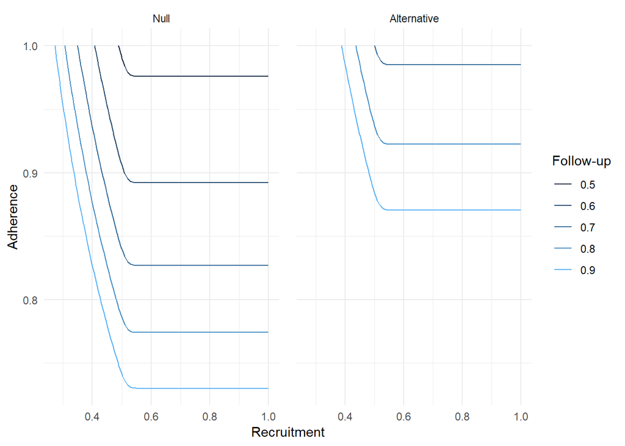

```r
get_exp_N <- function(n_e, n_t, phi_r)
{
  # Calculate the expected number recruited into the main trial
  n_r <- 0:(n_t-1)
  sum(dbinom(n_r, n_e, phi_r)*n_r) + n_t*(1-pbinom(n_t-1, n_e, phi_r))
}

get_fup <- function(phi, xi, mu, n_e, n_t)
{
  # For some recruitment and adherence rate, find the follow-up rate which will lie on
  # the boundary of the hypothesis defined by xi
  p_r <- phi[1]; p_a <- phi[2]; sd <- 1
  exp_n <- get_exp_N(n_e, n_t, p_r)
  (4*sd^2 + 2*mu^2 *p_a*(1-p_a))*xi^2/((p_a*mu)^2*exp_n)

}

# Null
df <- expand.grid(p_r=seq(0,1,0.01), p_a=seq(0,1,0.01))
df$p_f <- apply(df, 1, get_fup, xi=x0, mu=mu, n_e = 1000, n_t =514)
sub <- df

# Alternative
df <- expand.grid(p_r=seq(0,1,0.01), p_a=seq(0,1,0.01))
df$p_f <- apply(df, 1, get_fup, xi=x1, mu=mu, n_e = 1000, n_t =514)
sub_a <- df

# Combine for plotting
sub$h <- "Null"
sub_a$h <- "Alternative"
sub <- rbind(sub, sub_a)
# Discard any infeasible points
sub <- sub[sub$p_f <= 1,]

p <- ggplot(sub, aes(p_r, p_a, z=p_f, colour=p_f)) +
  geom_contour(aes(colour=..level..), breaks=c(0.5,0.6,0.7,0.8,0.9,1)) +
  theme_minimal() + xlab("Recruitment") + ylab("Adherence") +
  guides(colour = guide_legend(title = "Follow-up")) +
  facet_grid(. ~ factor(h, levels=c("Null", "Alternative"))) +
  theme(panel.spacing = unit(1, "lines"))
p
```

```r
#ggsave("./paper/figures/hyps.pdf", height=9, width=14, units="cm")
#ggsave("./paper/figures/hyps.eps", height=9, width=14, units="cm", device = cairo_ps())
```

### Local error rates

Having defined our hypotheses, we can now calculate local type I and II error rates for a proposed pilot trial with sample size $n$, critical value $c$, and at two specific points in the null and alternative hypotheses.

```r
# Using a c++ implemntation of forumla (X)
Rcpp::sourceCpp('./src/comp_ocs.cpp')

get_ocs <- function(y, n, x0, x1, mu=0.3, n_e, n_t, exp_ns)
{
  # Input y = (c, [point in null space], point in alternative space])
  c <- y[1]; sd <- 1

  # Under perfect adherence and follow-up, will need an expected sample size of at least
  # 4c^2 / mu^2
  # to get a positive result
  exp_ns <- exp_ns[exp_ns >= (4*c^2)/(mu^2)]

  # Probability of +ve result at the null point
  p_r <- y[2]; p_a <- y[3]; p_f <- y[4];
  alpha <- get_comp_ocs_cpp5(matrix(c(c, p_r, p_a, p_f, sd), ncol=5), exp_ns, n, mu, n_e, n_t)

  # Probability of -ve result at the alternative point
  p_r <- y[5]; p_a <- y[6]; p_f <- y[7];
  beta <- 1 - get_comp_ocs_cpp5(matrix(c(c, p_r, p_a, p_f, sd), ncol=5), exp_ns, n, mu, n_e, n_t)

  # Returning negative values for optimisation later
  return(-c(alpha, beta))
}

n <- 50; n_e <- 1000; n_t <- 514

exp_ns <- NULL
for(s in 0:1000){
  r_est <- 2*n/(s+2*n)
  x <- 0
  for(k in 0:(n_t-1)){
    x <- x + dbinom(k, n_e, r_est)*k
  }
  exp_ns <- c(exp_ns, x + n_t*(1 - pbinom(n_t-1, n_e, r_est)))
}
# Under perfect adherence and follow-up, will need an expected sample size of at least
# 4c^2 / mu^2
# to get a positive result
exp_ns <- exp_ns[exp_ns >= (4*2.46^2)/(mu^2)]

# For example,
get_ocs(c(2.4, 0.64, 0.73, 0.8769883, 0.96, 1, 0.7422108), 50, x0, x1, 0.3, 1000, 514, exp_ns=exp_ns)
```

```
## [1] -3.523243e-01 -6.223561e-08
```